# Transaction-Receipt Matcher

#### ABSTRACT

Our customers want the ability to automatically match receipt images to the associated transaction within the Banking app. Each of the data items returned from the external supplier was compared against the same data from the transaction, and a ‘transaction-receipt’ matching vector was created. The elements of the matching vector will be produced in different ways depending on the underlying data types being matched . We want to build a model to learn which matching features are the most successful. The ultimate goal is to match a single receipt to the correct transaction given a number of possible transactions however, given real world considerations, we want to sort the possible transactions for a given receipt in order of likelihood of being the correct transaction.

#### Aproach

First we will explore the data ,decide the evaluation metric in conjunction with Business objectve ,followed by some feature engineering that feeds into the model and finalize the baseline model after running a series of experiments . After finalizing the baseline model , we will attempt to improve the model to lift the performance metric(Discussed in later section) .

```python
from sklearn.metrics import classification_report, plot_confusion_matrix
from sklearn.model_selection import train_test_split
import sklearn
from random import shuffle
import numpy as np
import pandas as pd
import matplotlib.pyplot as plt
import xgboost


import seaborn as sns
import os
import pprint

import plotly.graph_objs as go
import plotly.tools as tls
from plotly.offline import iplot, init_notebook_mode
init_notebook_mode(connected=True)

#creating the objects
from sklearn.linear_model import LogisticRegression
from sklearn.ensemble import RandomForestClassifier
from sklearn.naive_bayes import GaussianNB
from sklearn.tree import DecisionTreeClassifier
from sklearn.svm import SVC
from sklearn import metrics
from sklearn.metrics import classification_report, accuracy_score
from sklearn.model_selection import cross_val_score
```

### **load dataset**

```python
data = pd.read_csv(r'data_interview_test.csv',sep=":")
data.head()
```

|  | receipt_id | company_id | matched_transaction_id | feature_transaction_id | DateMappingMatch | AmountMappingMatch | DescriptionMatch | DifferentPredictedTime | TimeMappingMatch | PredictedNameMatch | ShortNameMatch | DifferentPredictedDate | PredictedAmountMatch | PredictedTimeCloseMatch |
| --- | --- | --- | --- | --- | --- | --- | --- | --- | --- | --- | --- | --- | --- | --- |
| 0 | 10,000 | 10000 | 10,468 | 10,000 | 0.0 | 0.0 | 0.0 | 1.0 | 0.0 | 0.0 | 0.0 | 1.0 | 0.0 | 0.0 |
| 1 | 10,000 | 10000 | 10,468 | 10,001 | 0.0 | 0.0 | 0.0 | 1.0 | 0.0 | 0.0 | 0.0 | 1.0 | 0.0 | 0.0 |
| 2 | 10,000 | 10000 | 10,468 | 10,003 | 0.0 | 0.0 | 0.0 | 1.0 | 0.0 | 0.0 | 0.0 | 1.0 | 0.0 | 0.0 |
| 3 | 10,000 | 10000 | 10,468 | 10,004 | 0.0 | 0.0 | 0.0 | 1.0 | 0.0 | 0.0 | 0.0 | 1.0 | 0.0 | 0.0 |
| 4 | 10,000 | 10000 | 10,468 | 10,005 | 0.0 | 0.0 | 0.0 | 1.0 | 0.0 | 0.0 | 0.0 | 1.0 | 0.0 | 0.0 |

### Shape of dataset

```python
data.shape
```

```
(12034, 14)
```

We have total 12034 samples and each have mathcing feature vector of size of 10

### Create Target labels

- Transaction and Receipt are correct matches where matched_transaction_id = feature_transaction_id
- We create a column for the labels using above condition

```python
data['label']= (data.matched_transaction_id == data.feature_transaction_id).astype(int)
```

### Exploring distribution of target variable ( or correct vs wrong matches)

```
0    11177
1      857
Name: label, dtype: int64
```

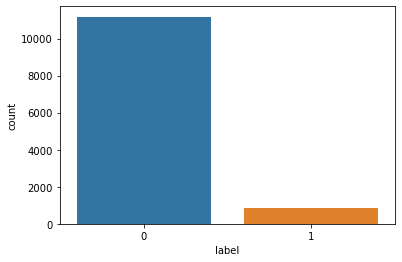

```python
sns.countplot(x=data['label'])
print(data.label.value_counts())
```

## Deciding Evaluation Metric

- So which model will perform best in this use case?
- Simple accuracy is bad metric here due to highly imbalanced data as randomly labeling as all incorrect matching the accuracy will be very high.
- Recall = true positives/(true positives + false negatives)
- Precison = true positives/(true positives + false positives) - **Recall** could be looked as ability of model to correctly label all true positives and precison is the fraction of relevant instances among the retrieved instances.
- Both of these are important but the objective is to to get a high Recall, so that all relevant correct matchings could be found from all the actual possible correct matches.

## Baseline

### EXPLORATORY DATA ANALYSIS

```python
data.isna().sum()
```

```
receipt_id                 0
company_id                 0
matched_transaction_id     0
feature_transaction_id     0
DateMappingMatch           0
AmountMappingMatch         0
DescriptionMatch           0
DifferentPredictedTime     0
TimeMappingMatch           0
PredictedNameMatch         0
ShortNameMatch             0
DifferentPredictedDate     0
PredictedAmountMatch       0
PredictedTimeCloseMatch    0
label                      0
dtype: int64
```

```python
data.info()
```

```
<class 'pandas.core.frame.DataFrame'>
RangeIndex: 12034 entries, 0 to 12033
Data columns (total 15 columns):
 #   Column                   Non-Null Count  Dtype
---  ------                   --------------  -----
 0   receipt_id               12034 non-null  object
 1   company_id               12034 non-null  int64
 2   matched_transaction_id   12034 non-null  object
 3   feature_transaction_id   12034 non-null  object
 4   DateMappingMatch         12034 non-null  float64
 5   AmountMappingMatch       12034 non-null  float64
 6   DescriptionMatch         12034 non-null  float64
 7   DifferentPredictedTime   12034 non-null  float64
 8   TimeMappingMatch         12034 non-null  float64
 9   PredictedNameMatch       12034 non-null  float64
 10  ShortNameMatch           12034 non-null  float64
 11  DifferentPredictedDate   12034 non-null  float64
 12  PredictedAmountMatch     12034 non-null  float64
 13  PredictedTimeCloseMatch  12034 non-null  float64
 14  label                    12034 non-null  int32
dtypes: float64(10), int32(1), int64(1), object(3)
memory usage: 1.3+ MB
```

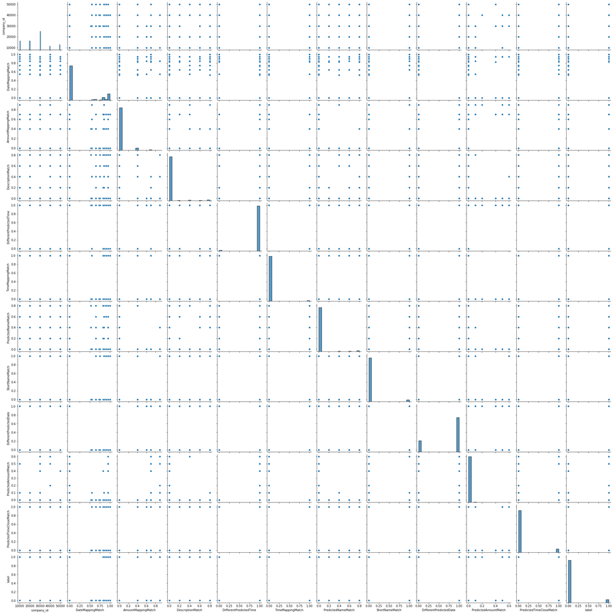

```python
sns.pairplot(data)
```

```python
### not much relation is seen within variables but some variables are clearly imbalanced.
```

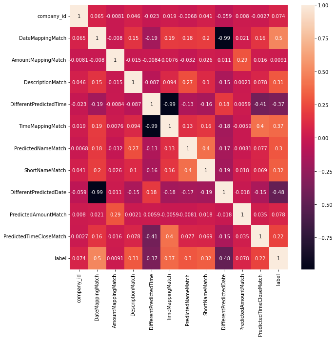

```python
f,ax=plt.subplots(figsize=(10,10))
sns.heatmap(data.corr(),annot=True,ax=ax)
plt.show()
```

###### Date and Time related features have close corelation about 0.99 , going forward we may drop one of them as they seem to hold duplicate information

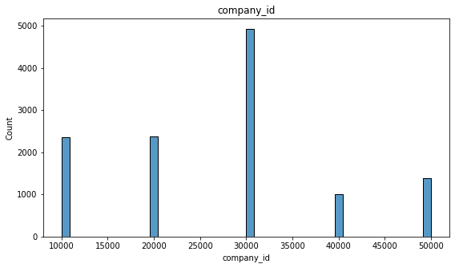

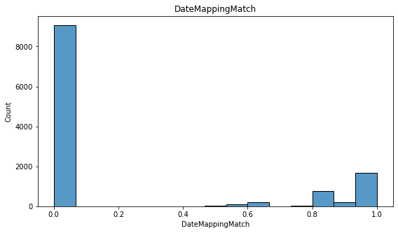

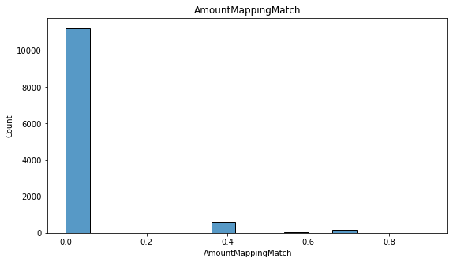

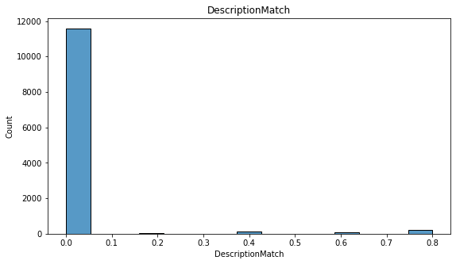

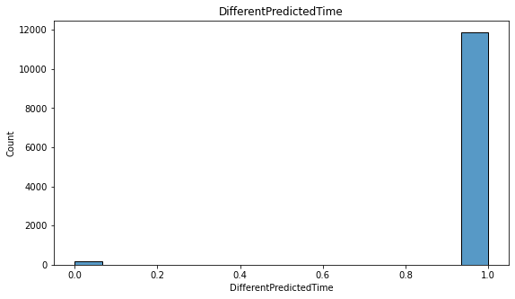

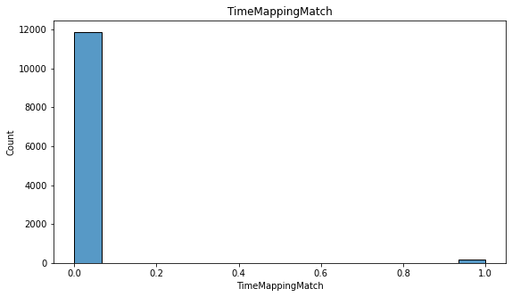

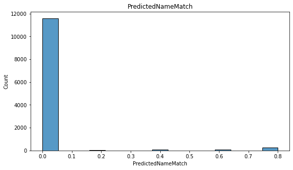

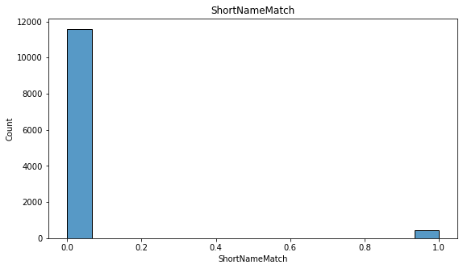

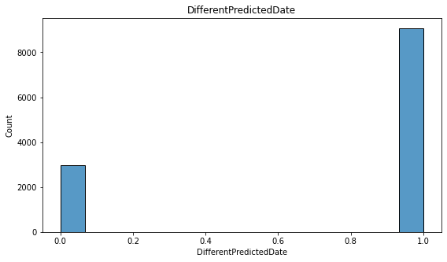

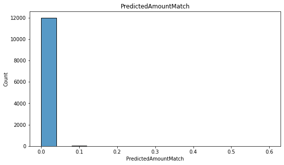

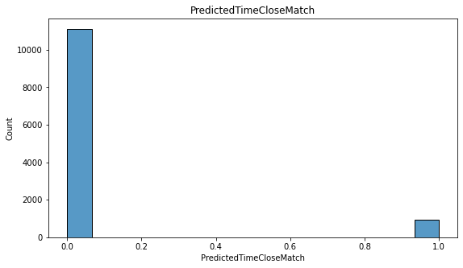

```python
numeric_data = data.select_dtypes(include=np.number) # select_dtypes selects data with numeric features
numeric_col = numeric_data.columns
for column in numeric_col:
    if column!='label':
        plt.figure(figsize=(20,5))
        plt.subplot(121)
        sns.histplot(data[column])
        plt.title(column)
```

##### except company id , the values are either 0 or 1 for most of the variables with imbalanced distribution.Also , all values lie in range of 0-1.

### Are there any Outliers ?

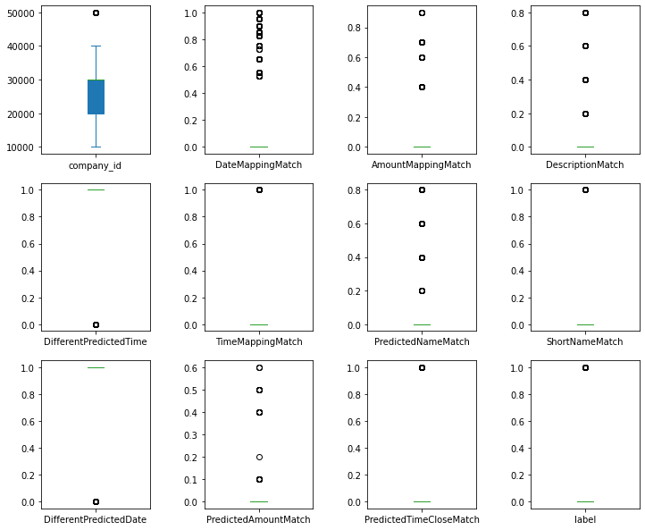

```python
# select columns to plot
df_to_plot = data.copy()
# subplots
df_to_plot.plot(subplots=True, layout=(4,4), kind='box', figsize=(12,14), patch_artist=True)
plt.subplots_adjust(wspace=0.5)
```

##### Most of the variables are extreme values , since we dont know how these vectors were generated , we would leave outlier treatment as of now and if we remove them , it would lead to data loss.

```python
import plotly.express as px
fig = px.scatter(data, x="DateMappingMatch", y="label")
fig.show()
```

[interactive chart not shown]

```python
fig=px.histogram(data,x="DateMappingMatch")
print(" Distribution of DateMappingMatch ")
fig.show()
```

```
 Distribution of DateMappingMatch
```

[interactive chart not shown]

- It could be seen DateMappingMatch is 0 for more than 8k samples.
- We can check if this distribution is related to the label:

```
DateMappingMatch related to average label value
```

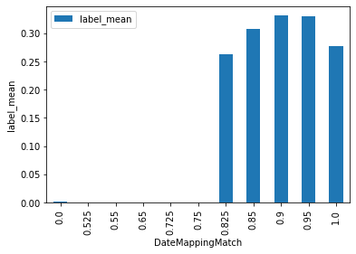

```python
dg = data.groupby('DateMappingMatch').agg({'label':['mean']})
dg.columns = ['label_mean']
ax = pd.DataFrame(dg.label_mean).plot.bar()
ax.set_ylabel('label_mean')

print ("DateMappingMatch related to average label value ")
```

- Now it could be seen here that for DateMappingMatch values > 0.8 the corresponds to higher label mean, or larger DateMappingMatch value is related to positive label.

### BASELINE MODEL

Using Cross validation to see the best model

```python
data['label']= (data.matched_transaction_id == data.feature_transaction_id).astype(int)
x,y = data[list(data.columns[4:])], data.label
x=x.drop(['label'], axis=1)
X_train, X_test, y_train, y_test = train_test_split(x, y, test_size=0.3, random_state=42,shuffle=True)

logreg_cv = LogisticRegression(solver='lbfgs', max_iter=1000)
dt_cv=DecisionTreeClassifier()
rf=RandomForestClassifier()
svc_cv=SVC()
nb_cv=GaussianNB()
cv_dict = {0: 'Random Forest', 1: 'Decision Tree',2:'KNN',3:'SVC',4:'Naive Bayes',5:'Logistic Regression'}
cv_models=[rf,dt_cv,nb_cv,rf,logreg_cv]

### cross validation

for i,model in enumerate(cv_models):
    print("{} accuracy: {}".format(cv_dict[i],cross_val_score(model, X_train, y_train, cv=10, scoring ='accuracy').mean()))
for i,model in enumerate(cv_models):
    print("{} Recall: {}".format(cv_dict[i],cross_val_score(model, X_train, y_train, cv=10, scoring ='recall').mean()))
```

[output not shown]

##### High Accuracy like above 90% is not a correct metric here. The recall achieved is not good highest being 0.61, let us try to achieve a higher recall .

Convert the dataset into an optimized data structure called Dmatrix that XGBoost supports and gives it acclaimed performance and efficiency gains.

```python
train = xgboost.DMatrix(X_train, label=y_train)
test = xgboost.DMatrix(X_test, label=y_test)
watchlist = [(test, 'eval'), (train, 'train')]

xgb_params = {
            'objective': 'binary:logistic',
            'tree_method': 'gpu_hist',
            'max_depth': 2,
            'eta':0.1,
            'silent':1,
            'subsample':0.5,
            'colsample_bytree': 0.05,

}

clf = xgboost.train( xgb_params,train, num_boost_round=10000, )

preds = clf.predict(test)
```

[output not shown]

```
              precision    recall  f1-score   support

           0       0.97      0.99      0.98      3349
           1       0.80      0.61      0.69       262

    accuracy                           0.96      3611
   macro avg       0.89      0.80      0.84      3611
weighted avg       0.96      0.96      0.96      3611

 In the Confusion Matrix below, the digonal values represent correct classification for each class :
```

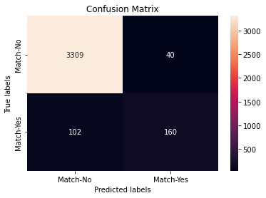

```python
print(classification_report((y_test),preds.round(0)))
print( " In the Confusion Matrix below, the digonal values represent correct classification for each class : ")
labels = ['Match-No', 'Match-Yes']

cm = sklearn.metrics.confusion_matrix((y_test),(preds.round(0).astype(int)))


ax= plt.subplot()
sns.heatmap(cm.astype(int), annot=True,fmt='g', ax = ax);

# labels, title and ticks
ax.set_xlabel('Predicted labels');ax.set_ylabel('True labels');
ax.set_title('Confusion Matrix');
ax.xaxis.set_ticklabels(labels); ax.yaxis.set_ticklabels(labels);
```

### MODEL IMPROVEMENTS

###### DATA IMBALANCE FEATURE ENGINEERING:

- The difference in weights will influence the classification of the classes during the training phase. The whole purpose is to penalize the misclassification made by the minority class by setting a higher class weight and at the same time reducing weight for the majority class.
- The best method would to have weighted loss, meaning if rare class is missclassifed the model would penalised more.
- We would specify a weight ratio, say 8.

[output not shown]

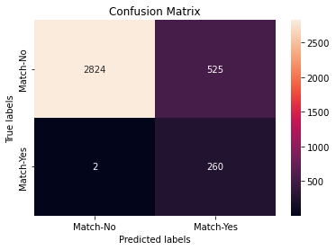

```python
data['label']= (data.matched_transaction_id == data.feature_transaction_id).astype(int)
x,y = data[list(data.columns[4:])], data.label
x=x.drop(['label'], axis=1)
X_train, X_test, y_train, y_test = train_test_split(x, y, test_size=0.3, random_state=42,shuffle=True)

train = xgboost.DMatrix(X_train, label=y_train)
test = xgboost.DMatrix(X_test, label=y_test)
watchlist = [(test, 'eval'), (train, 'train')]

xgb_params = {
            'objective': 'binary:logistic',
            'tree_method': 'gpu_hist',
            'max_depth': 2,
            'eta':0.1,
            'silent':1,
            'subsample':0.5,
            'colsample_bytree': 0.05,
            'scale_pos_weight':8,
}

clf = xgboost.train( xgb_params,train )

preds = clf.predict(test)

print(classification_report((y_test),preds.round(0)))

labels = ['Match-No', 'Match-Yes']

cm = sklearn.metrics.confusion_matrix((y_test),(preds.round(0).astype(int)))


ax= plt.subplot()
sns.heatmap(cm.astype(int), annot=True,fmt='g', ax = ax); #annot=True to annotate cells

# labels, title and ticks
ax.set_xlabel('Predicted labels');ax.set_ylabel('True labels');
ax.set_title('Confusion Matrix');
ax.xaxis.set_ticklabels(labels); ax.yaxis.set_ticklabels(labels);
```

- So adding weight to undersampled class has improved the recall value significantly,a high recall value of 0.99 is more preferable as it corresponds to correctly finding the matching reciept.
- Now as seen from Confusion Matrix, we can see we have more false postives (525)

```python
import pickle
file_name = "artifacts/xgb_best.pkl"

# save
pickle.dump(clf, open(file_name, "wb"))
```

##### FEATURE IMPORTANCE

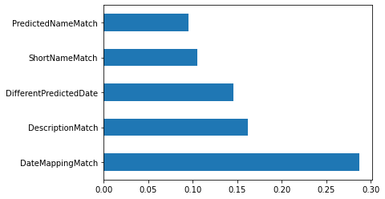

```python
rf.fit(X_train,y_train)
feat_importances = pd.Series(rf.feature_importances_, index=X_train.columns)
feat_importances.nlargest(5).plot(kind='barh')
plt.show()
```

### Next steps:

- We can try to select best hyperparmeters for the xgb model we are using to further improve the performance using Sklearn's scikit-optimize or HyperOpt that uses Bayesian Optimisation to get best model parameters.
- Also we can try to use stacking technique to combine classifiers and observe results.

### SUMMARY:

- A minimum viable product i.e a good classifier using XgBoost which is able to match the correct ‘transaction-receipt’ with high confidence was trained and saved.
- We chose 'Recall' as the evaluation metric.
- Hyper-Parameter search is hard for such kind of imbalanced data and low number of samples.
- Due to limited information on current feature vector, feature engineering is difficult and also outlier treatment was not carried out.
- Creating an ensemble of models can have resulted in little better performance but it's hard to deploy, so didn't attempt ensemble of models .